# Week 6, analysis of longitudal data

Lets see if there are any outliers in the data that might need to be removed:

```r
RATS_ <- RATSL %>%
  filter(Time > 0) %>%
  group_by(Group, ID) %>%
  summarise( mean=mean(weight) ) %>%
  ungroup()
glimpse(RATS_)
```

```
## Rows: 16
## Columns: 3
## $ Group <fct> 1, 1, 1, 1, 1, 1, 1, 1, 2, 2, 2, 2, 3, 3, 3, 3
## $ ID    <fct> 1, 2, 3, 4, 5, 6, 7, 8, 9, 10, 11, 12, 13, 14, 15, 16
## $ mean  <dbl> 261.0909, 237.6364, 260.1818, 266.5455, 269.4545, 274.7273, 274.~
```

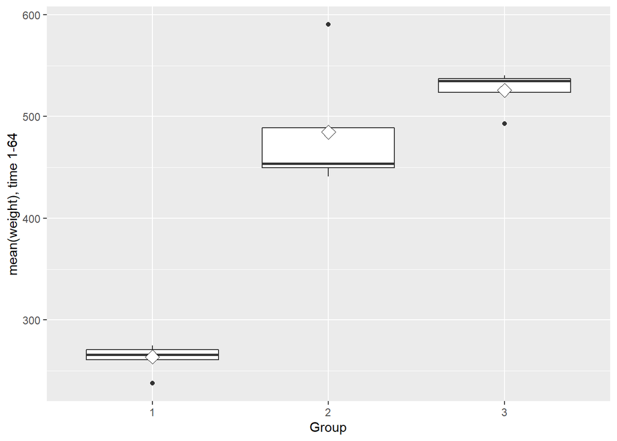

```r
ggplot(RATS_, aes(x = Group, y = mean)) +
  geom_boxplot() +
  stat_summary(fun.y = "mean", geom = "point", shape=23, size=4, fill = "white") +
  scale_y_continuous(name = "mean(weight), time 1-64")
```

There seems to be 3 outliers, lets remove them:

```r
RATS_1 <- filter(RATS_, ((RATS_$mean > 240 & RATS_$mean < 550))   )
RATS_1 <- filter(RATS_1, RATS_1$ID != 13)

glimpse(RATS_1)
```

```
## Rows: 13
## Columns: 3
## $ Group <fct> 1, 1, 1, 1, 1, 1, 1, 2, 2, 2, 3, 3, 3
## $ ID    <fct> 1, 3, 4, 5, 6, 7, 8, 9, 10, 11, 14, 15, 16
## $ mean  <dbl> 261.0909, 260.1818, 266.5455, 269.4545, 274.7273, 274.6364, 265.~
```

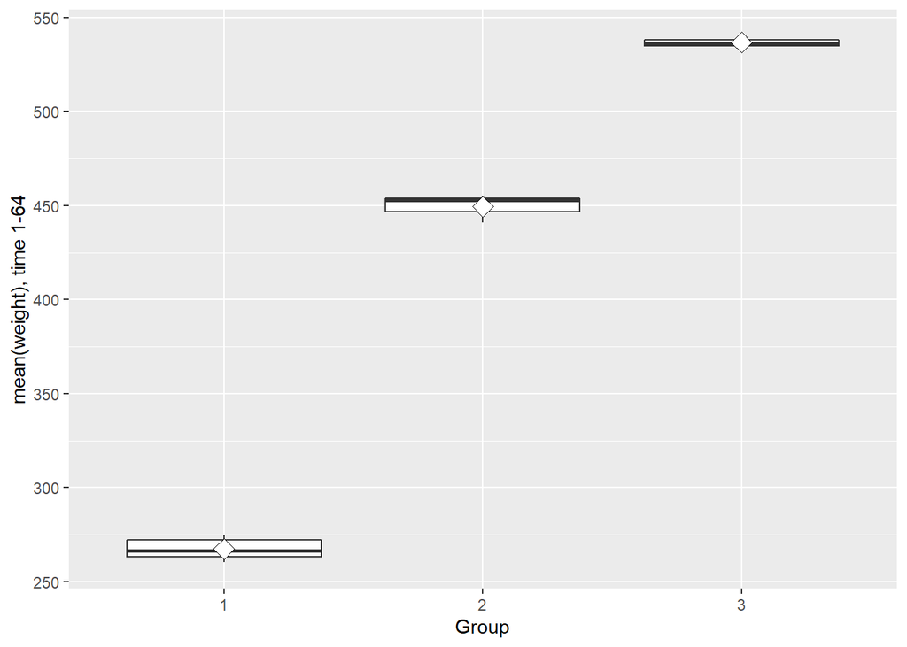

```r
ggplot(RATS_1, aes(x = Group, y = mean)) +
  geom_boxplot() +
  stat_summary(fun.y = "mean", geom = "point", shape=23, size=4, fill = "white") +
  scale_y_continuous(name = "mean(weight), time 1-64")
```

The outliers have been removed, lets see if there are differences between the groups according to a t-test:

```r
t.test(mean ~ Group, data = subset(RATS_1,RATS_1$Group != 1), var.equal = TRUE)
```

```
##
##  Two Sample t-test
##
## data:  mean by Group
## t = -18.428, df = 4, p-value = 5.102e-05
## alternative hypothesis: true difference in means between group 2 and group 3 is not equal to 0
## 95 percent confidence interval:
##  -100.45660  -74.14946
## sample estimates:
## mean in group 2 mean in group 3
##        449.4545        536.7576
```

```r
t.test(mean ~ Group, data = subset(RATS_1,RATS_1$Group != 2), var.equal = TRUE)
```

```
##
##  Two Sample t-test
##
## data:  mean by Group
## t = -73.22, df = 8, p-value = 1.348e-12
## alternative hypothesis: true difference in means between group 1 and group 3 is not equal to 0
## 95 percent confidence interval:
##  -277.7979 -260.8342
## sample estimates:
## mean in group 1 mean in group 3
##        267.4416        536.7576
```

```r
t.test(mean ~ Group, data = subset(RATS_1,RATS_1$Group != 3), var.equal = TRUE)
```

```
##
##  Two Sample t-test
##
## data:  mean by Group
## t = -41.656, df = 8, p-value = 1.215e-10
## alternative hypothesis: true difference in means between group 1 and group 2 is not equal to 0
## 95 percent confidence interval:
##  -192.089 -171.937
## sample estimates:
## mean in group 1 mean in group 2
##        267.4416        449.4545
```

```r
RATS_2 <- RATS_ %>% mutate(baseline = RATSL$weight[RATSL$Time == 1])

fit <- lm(mean ~ baseline + Group, data = RATS_2)

anova(fit)
```

```
## Analysis of Variance Table
##
## Response: mean
##           Df Sum Sq Mean Sq   F value    Pr(>F)
## baseline   1 252125  252125 2237.0655 5.217e-15 ***
## Group      2    726     363    3.2219   0.07586 .
## Residuals 12   1352     113
## ---
## Signif. codes:  0 '***' 0.001 '**' 0.01 '*' 0.05 '.' 0.1 ' ' 1
```

Based on the individual t-tests test statistics and p-values we can see that none of the groups have similar means thus the alternative hypothesis that the groups do not have similar means holds. The anova test we can see that baseline has a very low p-value and a large tests statistic thus it seems like the start weight of the rats is more important in this analysis rather than the diet the rats were put on.

#### Analysis of BPRS data:

```r
BPRSL <- read.table(file='data/BPRSL.tsv', sep = '\t')
BPRSL$treatment <- factor(BPRSL$treatment)
BPRSL$subject <- factor(BPRSL$subject)

dim(BPRSL) #360, 5
```

```
## [1] 360   5
```

```r
head(BPRSL)
```

```
##   treatment subject weeks bprs week
## 1         1       1 week0   42    0
## 2         1       2 week0   58    0
## 3         1       3 week0   54    0
## 4         1       4 week0   55    0
## 5         1       5 week0   72    0
## 6         1       6 week0   48    0
```

Again the data set has 5 variables that are the treatment group, subject ID, the rating on the test (bprs) and the different time points.

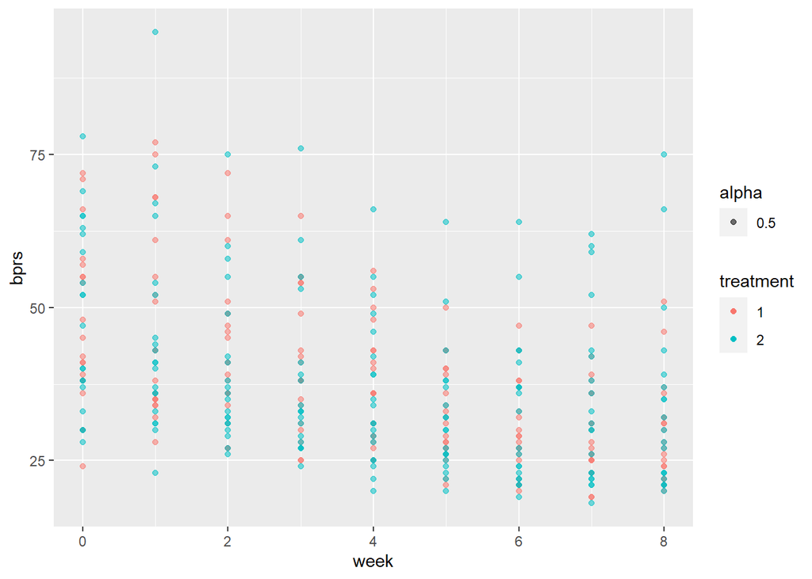

```r
ggplot(BPRSL, aes(x = week, y = bprs, group = subject, col = treatment, alpha = 0.5)) +
  geom_point()
```

```r
#  scale_x_continuous(name = "Time (weeks)") +
#  scale_y_continuous(name = "bprs") +
#  theme(legend.position = "top")
```

The line plot did not work for some reason, so I made a plot with points. I think it is overall hard to say anything about the different treatment groups based on this plot.

Lets do a regression and random intercept models next:

```r
library(lme4)
BPRSL_reg <- lm(bprs ~ week + treatment, data = BPRSL)
summary(BPRSL_reg)
```

```
##
## Call:
## lm(formula = bprs ~ week + treatment, data = BPRSL)
##
## Residuals:
##     Min      1Q  Median      3Q     Max
## -22.454  -8.965  -3.196   7.002  50.244
##
## Coefficients:
##             Estimate Std. Error t value Pr(>|t|)
## (Intercept)  46.4539     1.3670  33.982   <2e-16 ***
## week         -2.2704     0.2524  -8.995   <2e-16 ***
## treatment2    0.5722     1.3034   0.439    0.661
## ---
## Signif. codes:  0 '***' 0.001 '**' 0.01 '*' 0.05 '.' 0.1 ' ' 1
##
## Residual standard error: 12.37 on 357 degrees of freedom
## Multiple R-squared:  0.1851, Adjusted R-squared:  0.1806
## F-statistic: 40.55 on 2 and 357 DF,  p-value: < 2.2e-16
```

```r
BPRSL_ref <- lmer(bprs ~ week + treatment + (1|subject), data = BPRSL, REML = F)
summary(BPRSL_ref)
```

```
## Linear mixed model fit by maximum likelihood  ['lmerMod']
## Formula: bprs ~ week + treatment + (1 | subject)
##    Data: BPRSL
##
##      AIC      BIC   logLik deviance df.resid
##   2748.7   2768.1  -1369.4   2738.7      355
##
## Scaled residuals:
##     Min      1Q  Median      3Q     Max
## -3.0481 -0.6749 -0.1361  0.4813  3.4855
##
## Random effects:
##  Groups   Name        Variance Std.Dev.
##  subject  (Intercept)  47.41    6.885
##  Residual             104.21   10.208
## Number of obs: 360, groups:  subject, 20
##
## Fixed effects:
##             Estimate Std. Error t value
## (Intercept)  46.4539     1.9090  24.334
## week         -2.2704     0.2084 -10.896
## treatment2    0.5722     1.0761   0.532
##
## Correlation of Fixed Effects:
##            (Intr) week
## week       -0.437
## treatment2 -0.282  0.000
```

Based on the regression model the time that passes seems to be the most significant feature and that the treatment does not seem to be that important as it does not have a significant p-value. treatment group 2 also seems to have higher scores in the psychiatric test. The random intercept model again seems to show that the relationship between the intercept and the time that passes is significant. Treatment does not seem to be all that important in this model either.

Lets adjust the random intercept model and make a slope model.

```r
BPRSL_ref1 <- lmer(bprs ~ week + treatment + (week|subject) + (week * treatment), data = BPRSL, REML = F)
summary(BPRSL_ref1)
```

```
## Linear mixed model fit by maximum likelihood  ['lmerMod']
## Formula: bprs ~ week + treatment + (week | subject) + (week * treatment)
##    Data: BPRSL
##
##      AIC      BIC   logLik deviance df.resid
##   2744.3   2775.4  -1364.1   2728.3      352
##
## Scaled residuals:
##     Min      1Q  Median      3Q     Max
## -3.0512 -0.6271 -0.0768  0.5288  3.9260
##
## Random effects:
##  Groups   Name        Variance Std.Dev. Corr
##  subject  (Intercept) 64.9964  8.0620
##           week         0.9687  0.9842   -0.51
##  Residual             96.4707  9.8220
## Number of obs: 360, groups:  subject, 20
##
## Fixed effects:
##                 Estimate Std. Error t value
## (Intercept)      47.8856     2.2521  21.262
## week             -2.6283     0.3589  -7.323
## treatment2       -2.2911     1.9090  -1.200
## week:treatment2   0.7158     0.4010   1.785
##
## Correlation of Fixed Effects:
##             (Intr) week   trtmn2
## week        -0.650
## treatment2  -0.424  0.469
## wek:trtmnt2  0.356 -0.559 -0.840
```

It seems that the subject still adds a huge amount of variance and that time is still somewhat important but not as much as before. Week and treatmnet 2 seem to have some kind of correlation too.

```r
anova(BPRSL_ref, BPRSL_ref1)
```

```
## Data: BPRSL
## Models:
## BPRSL_ref: bprs ~ week + treatment + (1 | subject)
## BPRSL_ref1: bprs ~ week + treatment + (week | subject) + (week * treatment)
##            npar    AIC    BIC  logLik deviance  Chisq Df Pr(>Chisq)
## BPRSL_ref     5 2748.7 2768.1 -1369.4   2738.7
## BPRSL_ref1    8 2744.3 2775.4 -1364.1   2728.3 10.443  3    0.01515 *
## ---
## Signif. codes:  0 '***' 0.001 '**' 0.01 '*' 0.05 '.' 0.1 ' ' 1
```

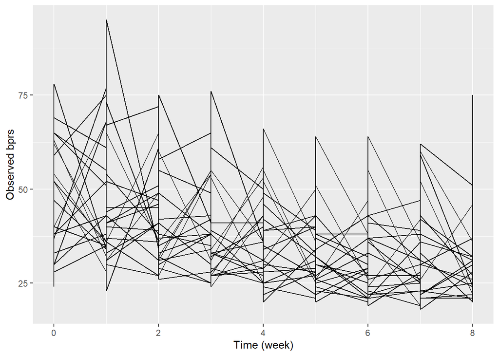

```r
ggplot(BPRSL, aes(x = week, y = bprs, group = subject)) +
  geom_line() +
  scale_x_continuous(name = "Time (week)") +
  scale_y_continuous(name = "Observed bprs") +
  theme(legend.position = "top")
```

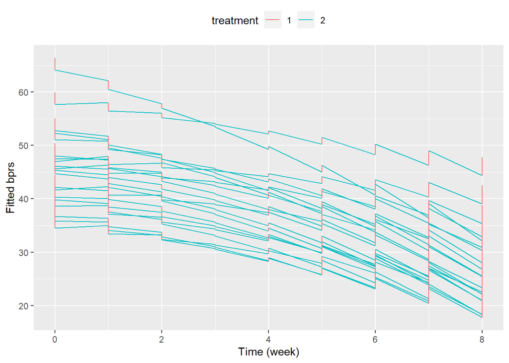

```r
BPRSL$fitted <- fitted(BPRSL_ref1)

ggplot(BPRSL, aes(x = week, y = fitted, group = subject, col = treatment)) +
  geom_line() +
  scale_x_continuous(name = "Time (week)") +
  scale_y_continuous(name = "Fitted bprs") +
  theme(legend.position = "top")
```

The line plots do not work all that well in this either, but in the fitted values plot we can see that the bprs value goes down as the time goes on. We can thus conclude that either both treatments had some kind of effect or that bprs scores going down are related to some other effect that is unrelated to the treatment groups.